# Decision Trees Homework

# MVP

## Question 1

Cleaning up the data is always the first step. Do the following:

- Take only observations which have a survived flag (i.e. that aren’t missing)
- Turn your important variables into factors (sex, survived, pclass, embarkation)
- Create an age_status variable which groups individuals under (and including) 16 years of age into a category called “child” category and those over 16 into a category called “adult”.
- Drop the NA
- Drop any variables you don’t need (X1, passenger_id, name, ticket, far, cabin)
- If you need help doing this, the code is below, but please try it yourself first so you can learn!

```r
titanic_clean <- titanic_set %>%
  filter(survived %in% c(0, 1)) %>%
  mutate(sex = as.factor(sex),
         survived = as.factor(levels = c(0, 1), labels = c("No", "Yes")),
         pclass = factor(levels = c(3, 2, 1), labels = c("Lower", "Middle", "Upper")),
         embarked = factor(levels = c("C", "Q", "S"), labels = c("Cherbourg", "Queenstown", "Southampton")),
         age_status = as.factor(if_else(age <= 16, "Child", "Adult")))
```

[output not shown]

## Question 2

Have a look at your data and create some plots to ensure you know what you’re working with before you begin. Write a summary of what you have found in your plots. Which variables do you think might be useful to predict whether or not people are going to die? Knowing this before you start is the best way to have a sanity check that your model is doing a good job.

My instinct is to first check total dead/survived numbers, then check the breakdown by passenger class, gender and age group:

| survived_flag | count |
| --- | --- |
| No | 424 |
| Yes | 288 |

```r
# Numbers dead/survived by passenger class
titanic_clean %>%
  group_by(class, survived_flag) %>%
  summarise(count = n())
```

| class | survived_flag | count |
| --- | --- | --- |
| Lower | No | 270 |
| Lower | Yes | 85 |
| Middle | No | 90 |
| Middle | Yes | 83 |
| Upper | No | 64 |
| Upper | Yes | 120 |

Majority of deaths looks to be in Lower class passengers.

```r
# Same, by gender
titanic_clean %>%
  group_by(sex, survived_flag) %>%
  summarise(count = n())
```

| sex | survived_flag | count |
| --- | --- | --- |
| female | No | 64 |
| female | Yes | 195 |
| male | No | 360 |
| male | Yes | 93 |

Mostly male passengers dying here, women and children first!

```r
# Same, by age status
titanic_clean %>%
  group_by(age_status, survived_flag) %>%
  summarise(count = n())
```

| age_status | survived_flag | count |
| --- | --- | --- |
| Adult | No | 379 |
| Adult | Yes | 233 |
| Child | No | 45 |
| Child | Yes | 55 |

Not surprised by this one, but mostly adult passengers dying.

[output not shown]

[output cut: 20 more lines]

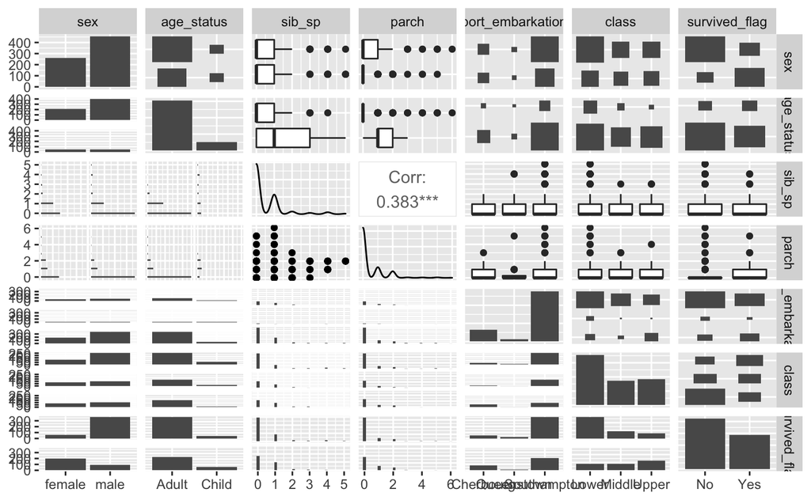

```r
titanic_clean %>%
  ggpairs()
```

From the `ggpairs` plot above, it seems like my first thoughts might be right to look at `class`, `age_status` and `sex`. `parch` and `embarked` could be significant too.

Not sure what’s going on with `sib_sp`!

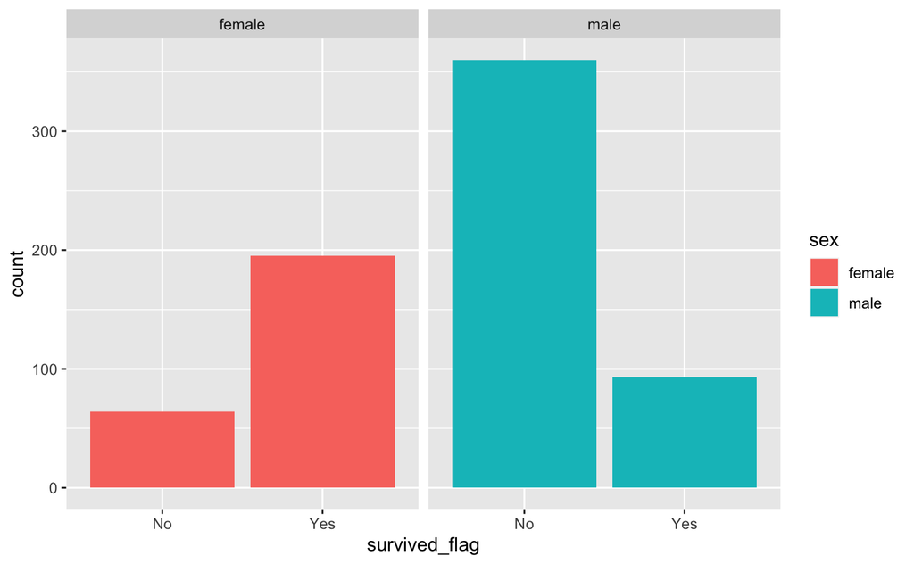

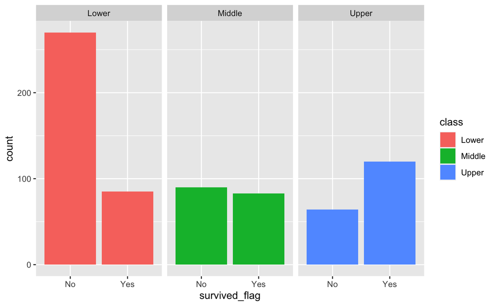

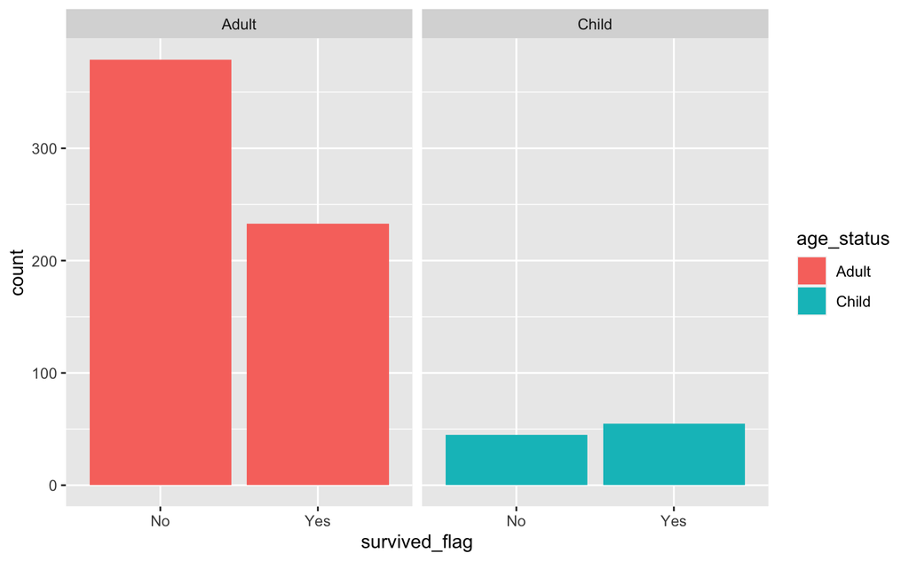

[figure not shown]

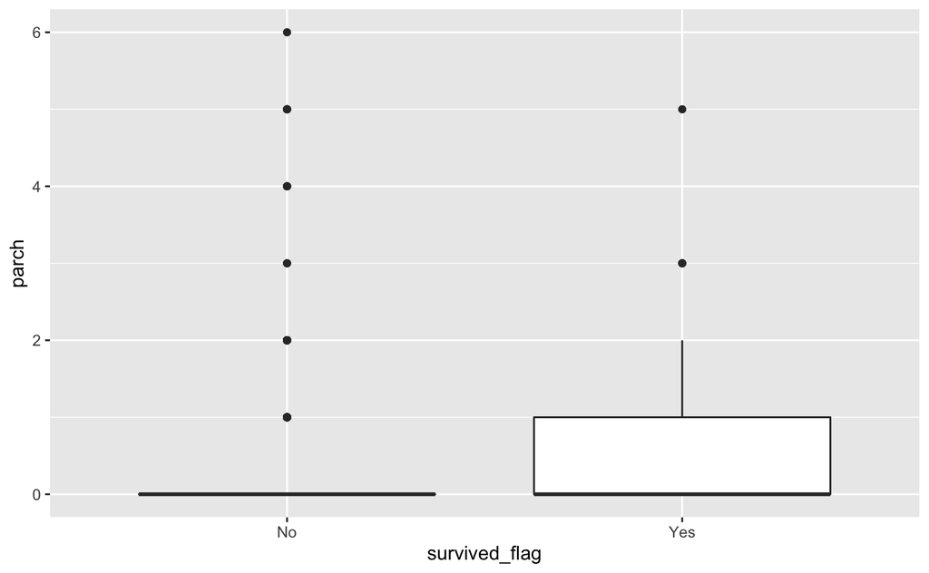

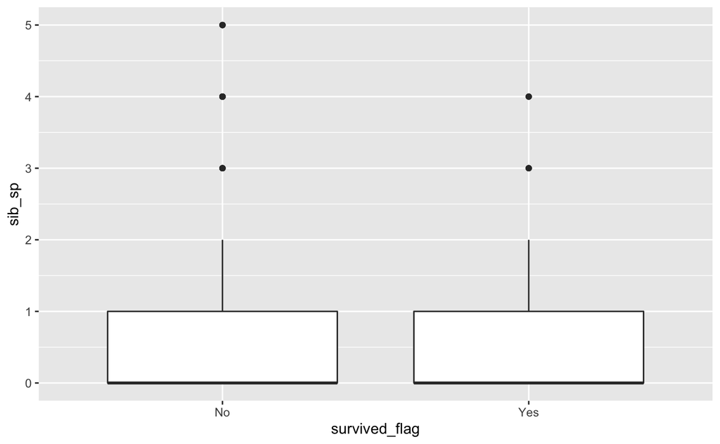

Summary:

- Female passengers more likely to survive than male
- Lower class passengers least likely to survive, upper class most likely to survive, middle class about even
- Adult passengers less likely to survive than children
- Passengers who embarked in Southampton least likely to suvive, those who embarked in Cherbourg most likely to survive (bit weird)
- Looks like passengers who travelled with parents or children are more likely to survive

## Question 3

## WARNING

### Exerything from here is different to what I’ve written about - when knitting it kept regenerating the decision tree. I’ve put some screenshots in the project folder.

Now you can start to build your model. Create your testing and training set using an appropriate split. Check you have balanced sets. Write down why you chose the split you did and produce output tables to show whether or not it is balanced.

I chose to use an 80/20 split for training/testing, because apparently thats good… (I’m not sure why we use this)

```r
library(janitor)

# Check training and testing set are balanced

titanic_train %>%
  tabyl(survived_flag)
```

```
 survived_flag   n   percent
            No 340 0.5964912
           Yes 230 0.4035088
```

```r
titanic_test %>%
  tabyl(survived_flag)
```

```
 survived_flag  n   percent
            No 84 0.5915493
           Yes 58 0.4084507
```

Took a few tries, but these are about as balanced as it can get.

## Question 4

Create your decision tree to try and predict survival probability using an appropriate method, and create a decision tree plot.

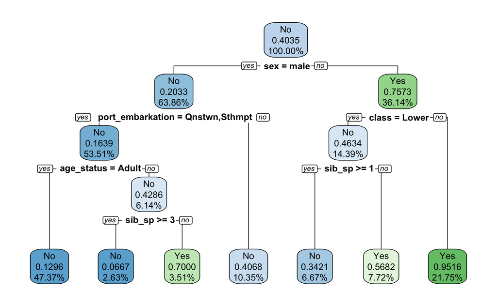

```r
# Create decision tree model and then plot
titanic_fit <- rpart(
  formula = survived_flag ~ .,
  data = titanic_train,
  method = 'class'
)

rpart.plot(titanic_fit,
           yesno = 2,
           fallen.leaves = TRUE,
           faclen = 6,
           digits = 4)
```

## Question 5

Write down what this tells you, in detail. What variables are important? What does each node tell you? Who has the highest chance of surviving? Who has the lowest? Provide as much detail as you can.

The most significant variable is sex, with female passengers having a 75% change of survival compared to 20% for male.

Female passengers who are not Lower class have a 95% chance of survival - the highest from the dataset.

## Question 6

Test and add your predictions to your data. Create a confusion matrix. Write down in detail what this tells you for this specific dataset.

| sex | age_status | sib_sp | parch | port_embarkation | class | survived_flag | pred |
| --- | --- | --- | --- | --- | --- | --- | --- |
| male | Adult | 0 | 0 | Cherbourg | Lower | No | No |
| male | Child | 5 | 2 | Southampton | Lower | No | No |
| male | Adult | 1 | 5 | Southampton | Lower | No | No |
| male | Adult | 0 | 0 | Southampton | Middle | Yes | No |
| female | Adult | 0 | 0 | Southampton | Lower | No | Yes |
| female | Adult | 0 | 0 | Southampton | Lower | No | Yes |
| male | Adult | 1 | 0 | Southampton | Upper | Yes | No |
| male | Adult | 0 | 0 | Southampton | Lower | No | No |
| female | Adult | 0 | 0 | Cherbourg | Upper | Yes | Yes |
| male | Adult | 0 | 0 | Southampton | Upper | Yes | No |

[output cut: 132 more lines]

```r
confusionMatrix(titanic_test_pred$pred, titanic_test_pred$survived_flag)
```

```
Confusion Matrix and Statistics

          Reference
Prediction No Yes
       No  72  18
       Yes 12  40

               Accuracy : 0.7887
                 95% CI : (0.7123, 0.8527)
    No Information Rate : 0.5915
    P-Value [Acc > NIR] : 5.164e-07

                  Kappa : 0.5557

 Mcnemar's Test P-Value : 0.3613

            Sensitivity : 0.8571
            Specificity : 0.6897
         Pos Pred Value : 0.8000
         Neg Pred Value : 0.7692
             Prevalence : 0.5915
         Detection Rate : 0.5070
   Detection Prevalence : 0.6338
      Balanced Accuracy : 0.7734

       'Positive' Class : No
```

The confusion matrix shows that there were:

- 72 True Negatives
- 18 False Negatives
- 40 True Positives
- 12 False Positives

With an accuracy of around 79% - this isn’t too bad, but there’s clearly room for improvement.